## Introduction and Motivation

Gaming is one of the biggest industries in the world right now. Many enjoy playing them, but many others like myself would also agree that watching others play games can be equally as entertaining. Platforms such as Twitch allow streamers to play games live for their audiences, allowing for further interaction between creators and their fans. Not only do audiences get to see their favorite games be played, but they also get to engage with their favorite internet personalities as well. Because of this, our goal is to find out how large streamers keep their fans watching their content. This is why the data we are working with will be from the top 1000 streamers of 2020: we will be using the data science pipeline to find and analyze any relationships that may be present between the popularity of a streamer and other factors regarding their stream and viewership.

# Step 1: Data Collection

First, we need to import some common Python packages used for data science. The list is as follows:

```python
import pandas as pd # for data analysis
import numpy as np #for various mathematic and scientific functionalities
import matplotlib.pyplot as plt #for data visualization and linear regression modeling
from sklearn import linear_model #for using a linear regression model for machine learning
from sklearn.model_selection import train_test_split #for training our linear regression model
from sklearn import metrics as metrics #for testing our linear regression model
import seaborn as sbn #for data visualization
```

We'll gradually be going over what each one of these do throughout the data science pipeline, starting with Pandas. The data we're going to be working with can be downloaded from here: https://www.kaggle.com/aayushmishra1512/twitchdata

After downloading the .csv file and adding it to the same folder we're working with for this notebook, let's start by getting the data using Pandas:

```python
df = pd.read_csv("twitchdata-update.csv")
```

This will create a dataframe in which we can view the data from the .csv file. Let's see what it looks like:

```python
df
```

|  | Channel | Watch time(Minutes) | Stream time(minutes) | Peak viewers | Average viewers | Followers | Followers gained | Views gained | Partnered | Mature | Language |
| --- | --- | --- | --- | --- | --- | --- | --- | --- | --- | --- | --- |
| 0 | xQcOW | 6196161750 | 215250 | 222720 | 27716 | 3246298 | 1734810 | 93036735 | True | False | English |
| 1 | summit1g | 6091677300 | 211845 | 310998 | 25610 | 5310163 | 1370184 | 89705964 | True | False | English |
| 2 | Gaules | 5644590915 | 515280 | 387315 | 10976 | 1767635 | 1023779 | 102611607 | True | True | Portuguese |
| 3 | ESL_CSGO | 3970318140 | 517740 | 300575 | 7714 | 3944850 | 703986 | 106546942 | True | False | English |
| 4 | Tfue | 3671000070 | 123660 | 285644 | 29602 | 8938903 | 2068424 | 78998587 | True | False | English |
| ... | ... | ... | ... | ... | ... | ... | ... | ... | ... | ... | ... |
| 995 | LITkillah | 122524635 | 13560 | 21359 | 9104 | 601927 | 562691 | 2162107 | True | False | Spanish |
| 996 | 빅헤드 (bighead033) | 122523705 | 153000 | 3940 | 793 | 213212 | 52289 | 4399897 | True | False | Korean |
| 997 | 마스카 (newmasca) | 122452320 | 217410 | 6431 | 567 | 109068 | -4942 | 3417970 | True | False | Korean |
| 998 | AndyMilonakis | 122311065 | 104745 | 10543 | 1153 | 547446 | 109111 | 3926918 | True | False | English |
| 999 | Remx | 122192850 | 99180 | 13788 | 1205 | 178553 | 59432 | 2049420 | True | False | French |

1000 rows × 11 columns

We can see that the data has 1000 unique Twitch streamers and their data, and is ranked in order by their total watch time in minutes. The dataframe also has 11 columns, each containing different factors that we will be further analyizing in our data science pipeline.

# Step 2: Data Representation

The data looks fine as it is; the information is clearly laid out, and there aren't any missing values to account for in any of the columns, so no further sanitization of the data is needed. However, for the sake of simplicity, we will not consider whether or not a streamer is partnered or mature into our analysis. This is because the majority of the streamers listed are partnered and are for an audience under 18, so we instead want to focus on the other factors that may contribute to a streamer's success. As such, we will be dropping the two columns from the table:

```python
df = df.drop(columns = ['Partnered','Mature'])
df
```

|  | Channel | Watch time(Minutes) | Stream time(minutes) | Peak viewers | Average viewers | Followers | Followers gained | Views gained | Language |
| --- | --- | --- | --- | --- | --- | --- | --- | --- | --- |
| 0 | xQcOW | 6196161750 | 215250 | 222720 | 27716 | 3246298 | 1734810 | 93036735 | English |
| 1 | summit1g | 6091677300 | 211845 | 310998 | 25610 | 5310163 | 1370184 | 89705964 | English |
| 2 | Gaules | 5644590915 | 515280 | 387315 | 10976 | 1767635 | 1023779 | 102611607 | Portuguese |
| 3 | ESL_CSGO | 3970318140 | 517740 | 300575 | 7714 | 3944850 | 703986 | 106546942 | English |
| 4 | Tfue | 3671000070 | 123660 | 285644 | 29602 | 8938903 | 2068424 | 78998587 | English |
| ... | ... | ... | ... | ... | ... | ... | ... | ... | ... |
| 995 | LITkillah | 122524635 | 13560 | 21359 | 9104 | 601927 | 562691 | 2162107 | Spanish |
| 996 | 빅헤드 (bighead033) | 122523705 | 153000 | 3940 | 793 | 213212 | 52289 | 4399897 | Korean |
| 997 | 마스카 (newmasca) | 122452320 | 217410 | 6431 | 567 | 109068 | -4942 | 3417970 | Korean |
| 998 | AndyMilonakis | 122311065 | 104745 | 10543 | 1153 | 547446 | 109111 | 3926918 | English |
| 999 | Remx | 122192850 | 99180 | 13788 | 1205 | 178553 | 59432 | 2049420 | French |

1000 rows × 9 columns

The columns for our dataset now read as follows:

Channel - Name of the streamer

Watch time(minutes) - Total accumulated watch time throughout 2020

Stream time(minutes) - Total time streamed throughout 2020

Peak viewers - The maximum number of viewers present in a stream at one time

Average viewers - Average number of viewers per stream

Followers - Number of followers the streamer has at at the time of recording the data

Followers gained - Number of followers gained throughout 2020

Views gained - Number of views gained throughout 2020

Language - language spoken by the streamer

# Step 3: Exploratory Data Analysis

First, we need to consider what we want to define as "popularity." Twitch ranks its streamers through a combination of concurrent viewers, followers, views, and time streamed. However, we will be going with the same ranking of popularity that the dataframe uses in our exploratory data analysis phase. Twitch's measurement of "popularity" consists of too many variables to work with in our analysis, so for the sake of simplicity, we will only be using the total watch time in minutes to determine popularity. This way, we have one specific variable we are looking for if we want better insight into what makes a streamer successful. Going off my intuition of how the platform works, I believe that the more content a streamer produces, the more likely they're going to garner views. So first, let's analyze the relationship between total watch time and stream time using Seaborn to create a scatterplot:

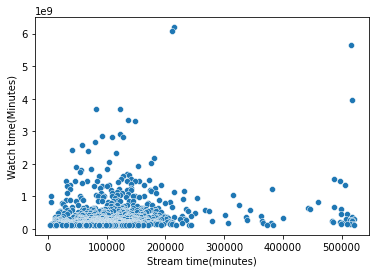

```python
sbn.scatterplot(x=df['Stream time(minutes)'],y=df['Watch time(Minutes)'])
```

Looks like I assumed incorrectly. Intuitively, we can tell that there isn't a strong correlation between the two variables, because as the independent variable (in this case, stream time in minutes) gets larger, we don't really see the dependent variable (watch time in minutes) get larger with it. Let's try something else then; we'll find the relationship between the peak viewers per stream and watch time:

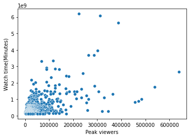

```python
sbn.scatterplot(x=df['Peak viewers'],y=df['Watch time(Minutes)'])
```

The correlation here is already much stronger; we can see that there is a positive correlation between the two variables, since as the independent variable increases, so does the dependent. Next, we'll see if there's any relationship between watch time and the average number of viewers per a creator's stream:

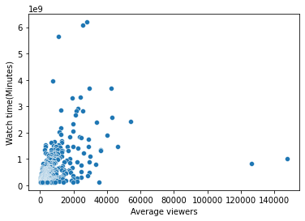

```python
sbn.scatterplot(x=df['Average viewers'],y=df['Watch time(Minutes)'])
```

Again, we see a positive correlation between the two variables, although not as strong as the last plot. Next, we'll see if there's any relationship between watch time and the number of followers a creator has:

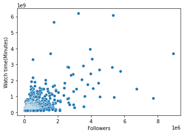

```python
sbn.scatterplot(x=df['Followers'],y=df['Watch time(Minutes)'])
```

Again, much clearer positive correlation between the two. Going off of what I predicted in the first example, I also assumed that a streamer who gains many followers would also have a high watch time. Let's see how accurate this is:

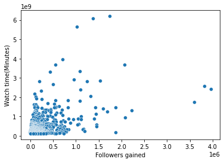

```python
sbn.scatterplot(x=df['Followers gained'],y=df['Watch time(Minutes)'])
```

Overall, the graph doesn't look much different from the previous one, so again, there exists a positive correlation between the two. Now let's plot the relationship between the number of views gained and time watched:

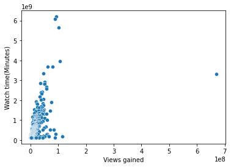

```python
sbn.scatterplot(x=df['Views gained'],y=df['Watch time(Minutes)'])
```

Doesn't seem like a strong correlation there. To better visualize which variables in the columns has had the strongest relationship with watch time, let's plot a heat map:

```
<function matplotlib.pyplot.show(close=None, block=None)>
```

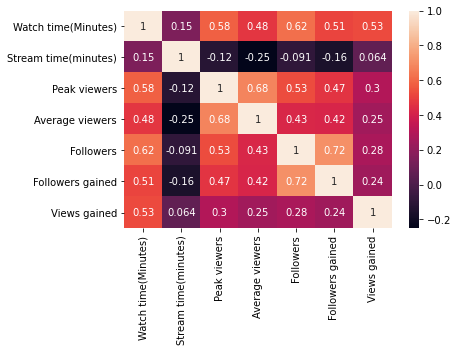

```python
plt.figure()
corr = df.corr()
sbn.heatmap(corr, annot=True)
plt.show
```

Let's plot one more scatterplot to see if there's any relationship between watch time and language:

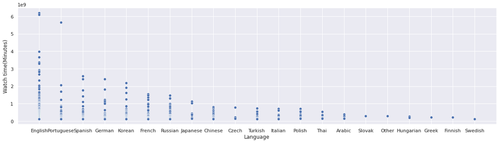

```python
sbn.set(rc={'figure.figsize':(20,5)})
sbn.scatterplot(x=df['Language'],y=df['Watch time(Minutes)'])
```

In this chart, we see that English speaking streamers tend to disproportionately have the most watch time, followed by Portuguese and Spanish and so on. This relationship will come into play later during our machine learning model, which we will need to revisit this chart and analyze it further.

Given that the correlation between followers and watch time was the highest, according to our heat map, we will be using that in our machine learning model to determine the linear relationship between the two variables.

# Step 4: Machine Learning

For this step, we're going to use the variables we chose from our exploratory data analysis (Followers) to predict the watch time a Twitch streamer could get if they had a random set of values for the aforementioned variable.

```python
train, test = train_test_split(df, train_size = 0.2)
```

We can now create a linear model from the training data and see how accurate it is in predicting watch time. For the x training and testing set, the variables will be the same as the ones we picked out from before. The y training and testing set will use watch time, the dependent variable. We will then fit them into a linear regression model, and allow it to make a prediction given our samples:

```python
#we assign each training set to their respective columns in the dataframe
x_train = train[["Followers"]]
x_test = test[["Followers"]]
y_train = train["Watch time(Minutes)"]
y_test = test["Watch time(Minutes)"]
#this will create our linear regression model
reg = linear_model.LinearRegression()
reg.fit(x_train, y_train)
#now we will make predictions using our model on the randomly selected test data
y_train_pred = reg.predict(x_train)
y_test_pred = reg.predict(x_test)
```

After getting our predictions for both the training and test sets, it's time to get some regression metrics from the model so that we can gauge how accurate it was in determining watch time. The metrics we'll be using are listed here on the Scikit Learn documentation: https://scikit-learn.org/stable/modules/model_evaluation.html#r2-score

We will only be calculating:

Explained Variance: the proportion to which our model accounts for the variation of a data set- the closer to 1, the better.

R-squared: how close the variables are to the regression model- again, the closer the value is to 1 the better.

Let's see what these evaluate to using metrics from Scikit Learn:

```python
explained_variance=metrics.explained_variance_score(y_train, y_train_pred)
print('Explained Variance: ', explained_variance)
print('r squared: ', reg.score(x_train, y_train))
```

```
Explained Variance:  0.4586447305557694
r squared:  0.4586447305557694
```

So far, the results from the training data doesn't seem to be that strong, as there is a lot of variance among the errors. Let's see how the test data does:

```python
explained_variance=metrics.explained_variance_score(y_test, y_test_pred)
print('Explained Variance: ', explained_variance)
print('r squared: ', reg.score(x_test, y_test))
```

```
Explained Variance:  0.35037717629012466
r squared:  0.34345675508325524
```

As mentioned before, we want both values to be as close to 1 as possible. However, with values as low as these, this is a clear indication that we are in need of a more refined model for calculating linear relationships, and that just going by the number of followers a streamer has is not enough to determine their total watch time.

In our exploratory data analysis and in the heat map, we've observed that there are multiple different independent variables that also have a strong correlation with watch time besides just Followers. These include Peak viewers, Average viewers, Followers gained, and Views gained. So it seems that instead of using just a simple linear regression model for our data, we need to use a multiple regression model. That way, we are able to explain the relationship between our single dependent variable and various other independent variables. Though it will be more difficult to visualize, it will hopefully allow us to create a better predictor for our values. So let's try again, this time by training x on multiple variables:

```python
x_train = train[["Peak viewers", "Average viewers", "Followers", "Followers gained", "Views gained"]]
x_test = test[["Peak viewers", "Average viewers", "Followers", "Followers gained", "Views gained"]]
# y train and test stays the same because we are still operating on the same dependent variable
y_train = train["Watch time(Minutes)"]
y_test = test["Watch time(Minutes)"]
reg = linear_model.LinearRegression()
reg.fit(x_train, y_train)
y_train_pred = reg.predict(x_train)
y_test_pred = reg.predict(x_test)
```

Now that we have our predictions ready, let's see how it holds up compared to our previous model:

```python
explained_variance=metrics.explained_variance_score(y_train, y_train_pred)
r2=metrics.r2_score(y_train, y_train_pred)
print('Explained Variance: ', explained_variance)
print('r squared: ', r2)
```

```
Explained Variance:  0.6466088293913987
r squared:  0.6466088293913987
```

Although these values aren't perfect, already we can tell that a multiple regression model is a more accurate way to predict the points in our data. Now let's do the same for our test values again:

```python
explained_variance=metrics.explained_variance_score(y_test, y_test_pred)
r2=metrics.r2_score(y_test, y_test_pred)
print('Explained Variance: ', explained_variance)
print('r squared: ', r2)
```

```
Explained Variance:  0.5218300615682432
r squared:  0.521510102639838
```

Now we need to test whether or not we should reject our null hypothesis, which states that there does not exist a relationship between peak viewers, average viewers, followers, followers gained, and views gained. We can do this by analyzing the relationship between the residuals for our new model (the distance between the actual plotted points and the linear regression model) and the total watch time in a histogram, which will show us the distribution of the differences between each point and the linear model:

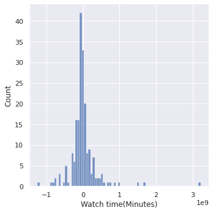

```python
residuals = (y_train - y_train_pred)
sbn.displot(residuals)
```

Here, we see a mostly symmetrical distribution where most of the values are clustered around 0, which is how we expect the relationship between the residuals and the watch time should look like. Therefore, we can reject the null hypothesis, because this indicates a linear relationship between the set of independent variables and the dependent variable.

## Back to Step 3?

The data science pipeline is sometimes a non-linear process. No matter which step you're currently on, if you feel that you need more information for your data analysis, you can always go back and redo a previous step with new insight you've acquired in a later step.

In our case, we need to go back to the exploratory data analysis step, since we discovered there that there exists a relationship between the language spoken and the total watch time as well. Using the residuals we found in step 4, we can go back and better analyze the relationship between the languages streamers speak and their popularity. First, let's make a violin plot (shows the maximum, minimum, and mean of data, as well as the density for certain values) using matplotlib for the relationship between residuals and languages:

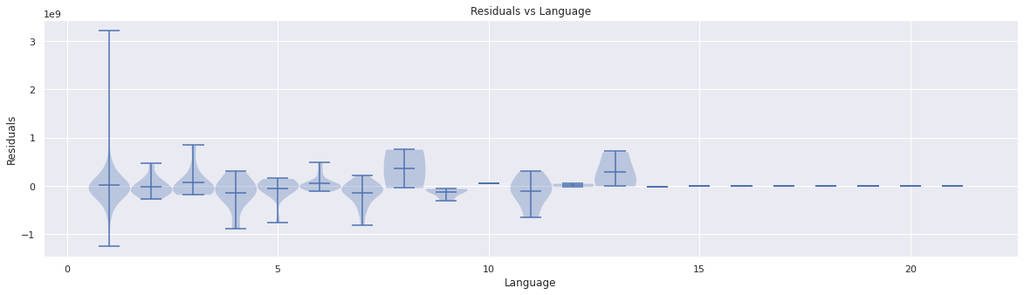

```python
# gets a list of languages exactly from the dataplot and a list of only unique entries
languages = df['Language']
language_list = df['Language'].unique()
# the two dimensional list has 21 elements for each of the 21 languages, and the order they appear in the dataplot is their index in the list
residuals_languages = [[],[],[],[],[],[],[],[],[],[],[],[],[],[],[0],[0],[0],[0],[0],[0],[0]]
#zeroes are added to the last lists in residuals per language to account for missing data

#using pyplot from matplotlib to create a violin plot
fig, ax = plt.subplots()
#plots all the residuals for their respective languages
for count, value in enumerate(residuals):
    if languages[count] == 'English':
        residuals_languages[0].append(value)
    elif languages[count] == 'Portuguese':
        residuals_languages[1].append(value)
    elif languages[count] == 'Spanish':
        residuals_languages[2].append(value)
    elif languages[count] == 'German':
        residuals_languages[3].append(value)
    elif languages[count] == 'Korean':
        residuals_languages[4].append(value)
    elif languages[count] == 'French':
        residuals_languages[5].append(value)
    elif languages[count] == 'Russian':
        residuals_languages[6].append(value)
    elif languages[count] == 'Japanese':
        residuals_languages[7].append(value)
    elif languages[count] == 'Chinese':
        residuals_languages[8].append(value)
    elif languages[count] == 'Czech':
        residuals_languages[9].append(value)
    elif languages[count] == 'Turkish':
        residuals_languages[10].append(value)
    elif languages[count] == 'Italian':
        residuals_languages[11].append(value)
    elif languages[count] == 'Polish':
        residuals_languages[12].append(value)
    elif languages[count] == 'Thai':
        residuals_languages[13].append(value)
    elif languages[count] == 'Arabic':
        residuals_languages[14].append(value)
    elif languages[count] == 'Slovak':
        residuals_languages[15].append(value)
    elif languages[count] == 'Other':
        residuals_languages[16].append(value)
    elif languages[count] == 'Hungarian':
        residuals_languages[17].append(value)
    elif languages[count] == 'Greek':
        residuals_languages[18].append(value)
    elif languages[count] == 'Finnish':
        residuals_languages[19].append(value)
    else:
        residuals_languages[20].append(value)
#converts the list of lists to an array so it can be plotted
residuals_languages = np.array(residuals_languages, dtype=object)
#the transpose of the array must be passed as an argument so the dimensions match for the plot
ax.violinplot(np.transpose(residuals_languages),widths=1,showmeans=True)
ax.set_xlabel("Language")
ax.set_ylabel("Residuals")
ax.set_title("Residuals vs Language")
```

The "violins" shown in this chart appear in the same order that the languages do in the plot we made for step 3 (so English comes first, then Portuguese then so on).

# Step 5: Making Conclusions

Despite the name of this step, we cannot make any certain conclusions based on the patterns we've seen in the data. We have proven that there does indeed exist a linear relationship between a streamer's followers, average viewers, peak viewers, followers gained, and viewers gained, though there is a lot we can still unpack when questioning the certainty of this statement.

For example, we must also acknowledge that correlation doesn't mean causation. For example, although the number of followers and watch time a streamer have a linear relationship with each other, this does not prove that one causes the other or vice versa.

## Final Thoughts and Resources